# EQ17_TP2_Q2 - Commercialisation et prévisibilité du succès de produits

Jean-francois Paty (906250500)

Émie Smith Brousseau (111255191)

Leila Maouloud (111243344)

3 novembre 2019

```r
# Chargement des librairies nécessaires
library(tidyverse)
library(caret)
library(rpart.plot)
library(pROC)
```

# 1 Préparation des données

```r
# Chargement des données
filename_vin <- 'data/Q2_data.tsv'
data_vin <- read_tsv(filename_vin)

#Vérification des données manquantes:
data_vin %>%summarize(na_count = sum(is.na(.)))
```

```
## # A tibble: 1 x 1
##   na_count
##      <int>
## 1        0
```

```r
head(data_vin %>% filter_all(any_vars(is.na(.))),n=3)
```

```
## # A tibble: 0 x 18
## # ... with 18 variables: in01 <chr>, in02 <dbl>, in03 <dbl>, in04 <dbl>,
## #   in05 <dbl>, in06 <dbl>, in07 <dbl>, in08 <dbl>, in09 <chr>,
## #   in10 <dbl>, in11 <dbl>, in12 <dbl>, in13 <dbl>, in14 <dbl>,
## #   in15 <dbl>, in16 <chr>, in17 <dbl>, Class <chr>
```

```r
#Vérification du type de chaque colonne et du nombre d'observations:
str(data_vin)
```

```
## Classes 'spec_tbl_df', 'tbl_df', 'tbl' and 'data.frame': 6497 obs. of  18 variables:
##  $ in01 : chr  "white" "white" "white" "white" ...
##  $ in02 : num  0.0046 0.0079 0.0035 0.0099 0.0078 0.0083 0.0063 0.0012 0.037 0.0073 ...
##  $ in03 : num  0.09 0.1 0.03 0.02 0.05 0.03 0.03 0.04 0.54 0.06 ...
##  $ in04 : num  0.08 0.06 0.03 0.08 0.01 0.08 0.05 0.06 0.47 0.06 ...
##  $ in05 : num  0.02 0.02 0.01 0.04 0.04 0.01 0.03 0.03 0.38 0.06 ...
##  $ in06 : num  10.3 8.5 4.7 6.3 7.1 7.5 6.8 8.2 9.2 5.6 ...
##  $ in07 : num  0.17 0.18 0.785 0.39 0.32 0.29 0.22 0.42 0.36 0.2 ...
##  $ in08 : num  0.47 0.3 0 0.35 0.4 0.67 0.3 0.29 0.34 0.22 ...
##  $ in09 : chr  "very low" "very low" "low" "med" ...
##  $ in10 : num  0.037 0.028 0.036 0.04 0.034 0.037 0.07 0.03 0.062 0.049 ...
##  $ in11 : num  5 34 23 82 13 53 67 31 5 25 ...
##  $ in12 : num  33 95 134 260 84 166 194 100 12 155 ...
##  $ in13 : num  0.994 0.993 0.99 0.994 0.994 ...
##  $ in14 : num  2.89 2.83 3.53 3.12 3.42 2.9 2.89 3 3.2 3.74 ...
##  $ in15 : num  0.28 0.36 0.92 0.66 0.6 0.41 0.42 0.32 0.67 0.43 ...
##  $ in16 : chr  "low" "med" "high" "med" ...
##  $ in17 : num  24.1 26.4 28.9 27.7 19.6 ...
##  $ Class: chr  "no" "no" "no" "no" ...
##  - attr(*, "spec")=
##   .. cols(
##   ..   in01 = col_character(),
##   ..   in02 = col_double(),
##   ..   in03 = col_double(),
##   ..   in04 = col_double(),
##   ..   in05 = col_double(),
##   ..   in06 = col_double(),
##   ..   in07 = col_double(),
##   ..   in08 = col_double(),
##   ..   in09 = col_character(),
##   ..   in10 = col_double(),
##   ..   in11 = col_double(),
##   ..   in12 = col_double(),
##   ..   in13 = col_double(),
##   ..   in14 = col_double(),
##   ..   in15 = col_double(),
##   ..   in16 = col_character(),
##   ..   in17 = col_double(),
##   ..   Class = col_character()
##   .. )
```

```r
# Affichage de queslques lignes
head(data_vin)
```

```
## # A tibble: 6 x 18
##   in01    in02  in03  in04  in05  in06  in07  in08 in09    in10  in11  in12
##   <chr>  <dbl> <dbl> <dbl> <dbl> <dbl> <dbl> <dbl> <chr>  <dbl> <dbl> <dbl>
## 1 white 0.0046  0.09  0.08  0.02  10.3 0.17   0.47 very ~ 0.037     5    33
## 2 white 0.0079  0.1   0.06  0.02   8.5 0.18   0.3  very ~ 0.028    34    95
## 3 white 0.0035  0.03  0.03  0.01   4.7 0.785  0    low    0.036    23   134
## 4 white 0.0099  0.02  0.08  0.04   6.3 0.39   0.35 med    0.04     82   260
## 5 white 0.0078  0.05  0.01  0.04   7.1 0.32   0.4  very ~ 0.034    13    84
## 6 white 0.0083  0.03  0.08  0.01   7.5 0.290  0.67 very ~ 0.037    53   166
## # ... with 6 more variables: in13 <dbl>, in14 <dbl>, in15 <dbl>,
## #   in16 <chr>, in17 <dbl>, Class <chr>
```

```r
levels(data_vin$Class)
```

[output not shown]

```r
#Modification de la colonne Class en type Factor

data_vin$Class <- as.factor(data_vin$Class)
```

Il n’y a aucune données manquantes.

Selon l’énoncé du TP chaque colonne représente une caractéristique du vin. Nous conservons les colonnnes pour la contruction du modéle de classification.

```r
#Partitionnement des données en ensemble d’entraînement et de test

# fixation de la valeur de la variable aléatoire à 999
set.seed(999)

train_vin_index <- createDataPartition(y = data_vin$Class,
                                            p = 0.7,
                                            list = FALSE,
                                            times = 1)

#Création de la table d'observations pour l'entrainement
train_vin <- data_vin[train_vin_index,]

#Création de la table d'observations pour les tests
test_vin <- data_vin[-train_vin_index,]
```

# 2 Premier modéle : Arbre de décision

Le jeu de données d’entrainement contient 4548 obervations Le jeu de données de test contient 1949 obervations

## 2.1 Entrainement

### 2.1.1 Paramétre du modéle d’apprentissage Arbre de décision

La première étape consiste à préparer l’entraînement en configurant les routines qui permettront de sélectionner les meilleurs paramètres possible parmi un ensemble de paramètres choisis.

Ici, on indique que nous souhaitons faire une validation croisée en 10 partitions (10-fold cross-validation) :

```r
#validation croisée en 10 partitions (10-fold cross-validation)
dt_control <- trainControl(method= "cv", number=10)

#profondeur maximale de l'arbre:
dt_tune_grid = expand.grid(maxdepth = 1:25)
```

Selon la documentation de Caret, le modéle de type “rpart2” ne nécessite qu’un seul paramétre en entrée: maxdepth. maxdepth est un paramètre qui contrôle la profondeur maximale de l’arbre de décision créé par l’algorithme d’apprentissage. Nous faisons varier la valeur de 1 à 25

```r
#Création du modéle

dt_modele_rds_Q2 <- 'data/dt_modele_rds_Q2.rds'
if(!file.exists(dt_modele_rds_Q2)) {
  dt_model <- train(Class ~ .,
          data = train_vin,
          trControl = dt_control,
          method = 'rpart2',
          tuneGrid = dt_tune_grid)
  write_rds(dt_model, dt_modele_rds_Q2)
  } else {
    dt_model <- read_rds(dt_modele_rds_Q2)
          }
```

## 2.2 Évaluation avec les données d’entrainement

*Affichage du modéle*

Les meilleurs paramètres sont 7

```r
dt_model$finalModel
```

```
## n= 4548
##
## node), split, n, loss, yval, (yprob)
##       * denotes terminal node
##
##  1) root 4548 894 no (0.80343008 0.19656992)
##    2) in16standard< 0.5 3576 443 no (0.87611857 0.12388143)
##      4) in16low>=0.5 1809 106 no (0.94140409 0.05859591) *
##      5) in16low< 0.5 1767 337 no (0.80928127 0.19071873)
##       10) in16med>=0.5 1733 311 no (0.82054241 0.17945759) *
##       11) in16med< 0.5 34   8 yes (0.23529412 0.76470588) *
##    3) in16standard>=0.5 972 451 no (0.53600823 0.46399177)
##      6) in11< 21.5 356 127 no (0.64325843 0.35674157)
##       12) in15< 0.635 242  65 no (0.73140496 0.26859504) *
##       13) in15>=0.635 114  52 yes (0.45614035 0.54385965)
##         26) in12>=31.5 60  22 no (0.63333333 0.36666667) *
##         27) in12< 31.5 54  14 yes (0.25925926 0.74074074) *
##      7) in11>=21.5 616 292 yes (0.47402597 0.52597403)
##       14) in15< 0.475 356 158 no (0.55617978 0.44382022)
##         28) in09med< 0.5 297 117 no (0.60606061 0.39393939) *
##         29) in09med>=0.5 59  18 yes (0.30508475 0.69491525) *
##       15) in15>=0.475 260  94 yes (0.36153846 0.63846154) *
```

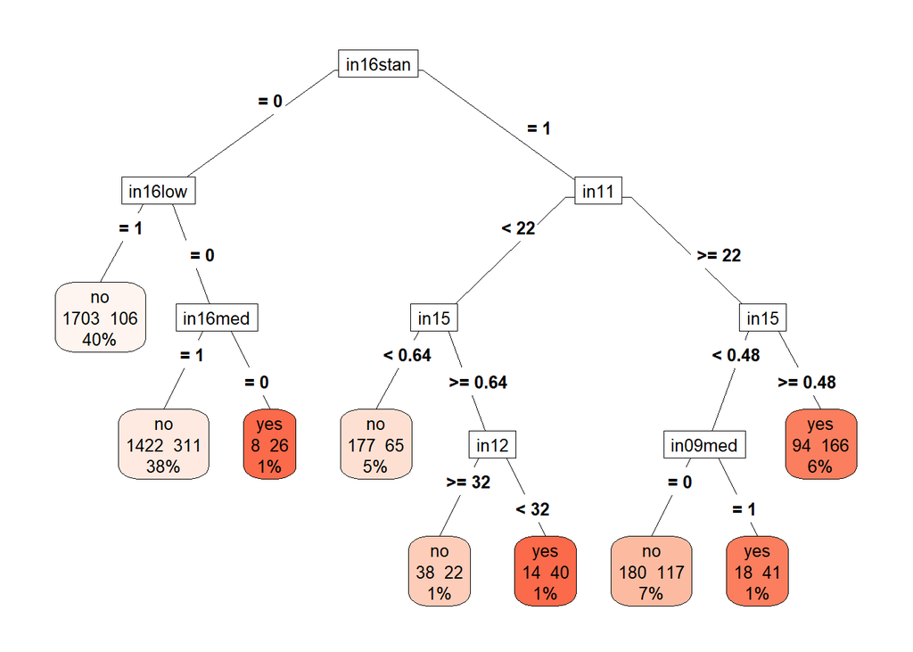

```r
#Représentataion graphique

prp(dt_model$finalModel,
  box.palette = "Reds",
  type = 5,
  extra = 101)
```

*Visualisation de la performance pendant l’entrainement*

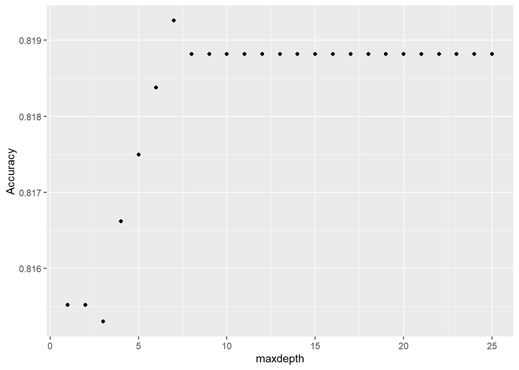

```r
#Visualisation de la performance durant l'entrainement
ggplot(dt_model$results,
       aes(x = maxdepth,
          y = Accuracy)) +
  geom_point()
```

On peut voir dans le graphique ci-dessus, que l’exactitude augmente fortement à partir de 3 jusqu’à 6. L’ exactitude se stabilise aprés 7.

*Visualisation du modéle avec les données d’entrainement*

Nous utilisons la matrice de confusion pour analyser la performance du modéle sur le critére de l’exactitude (Accuracy).

```r
# Prediction avec le jeu d'entrainement
dt_train_pred_class <- predict(dt_model, train_vin)

#Matrice de confusion avec le jeu d'entrainement

dt_train_conf_mat = confusionMatrix(dt_train_pred_class,
                reference = train_vin$Class,
                positive = 'yes')
dt_train_conf_mat
```

```
## Confusion Matrix and Statistics
##
##           Reference
## Prediction   no  yes
##        no  3520  621
##        yes  134  273
##
##                Accuracy : 0.834
##                  95% CI : (0.8229, 0.8447)
##     No Information Rate : 0.8034
##     P-Value [Acc > NIR] : 6.718e-08
##
##                   Kappa : 0.3383
##
##  Mcnemar's Test P-Value : < 2.2e-16
##
##             Sensitivity : 0.30537
##             Specificity : 0.96333
##          Pos Pred Value : 0.67076
##          Neg Pred Value : 0.85004
##              Prevalence : 0.19657
##          Detection Rate : 0.06003
##    Detection Prevalence : 0.08949
##       Balanced Accuracy : 0.63435
##
##        'Positive' Class : yes
##
```

Avec les données d’entrainement l’exactitude est de 0.833993

## 2.3 Evaluation du modéle avec les données de test

```r
# Prediction avec le jeu de test
dt_test_pred_class <- predict(dt_model, test_vin)
dt_test_pred_class %>% head(5)
```

```
## [1] no  yes no  no  no
## Levels: no yes
```

```r
#Matrice de confusion avec le jeu de test

dt_test_conf_mat = confusionMatrix(dt_test_pred_class,
                reference = test_vin$Class,
                positive = 'yes')
dt_test_conf_mat
```

```
## Confusion Matrix and Statistics
##
##           Reference
## Prediction   no  yes
##        no  1485  287
##        yes   81   96
##
##                Accuracy : 0.8112
##                  95% CI : (0.7931, 0.8283)
##     No Information Rate : 0.8035
##     P-Value [Acc > NIR] : 0.2048
##
##                   Kappa : 0.2496
##
##  Mcnemar's Test P-Value : <2e-16
##
##             Sensitivity : 0.25065
##             Specificity : 0.94828
##          Pos Pred Value : 0.54237
##          Neg Pred Value : 0.83804
##              Prevalence : 0.19651
##          Detection Rate : 0.04926
##    Detection Prevalence : 0.09082
##       Balanced Accuracy : 0.59946
##
##        'Positive' Class : yes
##
```

Avec les données de test l’exactitude est de 0.8111852

# 3 Deuxieme modéle : Réseau de neurones

## 3.1 Entrainement

Pour ce modéle nous retirons les colonnes qui sont au format caractére. Nous ne conservons que les colonnes numérique.

### 3.1.1 Paramétre du modéle d’apprentissage Réseau de neurones

Ici, on indique que nous souhaitons faire une validation croisée en 10 partitions (10-fold cross-validation) :

```r
#validation croisée en 10 partitions (10-fold cross-validation)
nn_control_Q2 <- trainControl(method= "cv", number=10)

nn_tune_grid_Q2 <-  expand.grid(decay = c(0, 0.01, .1),
                        size=c(0:10))
#Suppression des colonnes de type caractére
nn_train_col_purge <- select(train_vin, -in01, -in09, -in16)



nn_modele_rds_Q2 <- 'data/nn_modele_rds_Q2.rds'
if(!file.exists(nn_modele_rds_Q2)) {
  nn_model_Q2_purge <- train(Class ~ .,
                data = nn_train_col_purge,
                tunegrid = expand.grid(decay = c(0, 0.01, .1),
                                       size = c(1:10)),
                method = 'nnet',
                trControl = nn_control_Q2,
                preProc = c('center', 'scale'))
  write_rds(nn_model_Q2_purge, nn_modele_rds_Q2)
  } else {
    nn_model_Q2_purge <- read_rds(nn_modele_rds_Q2)
}
```

## 3.2 Évaluation avec les données d’entrainement

*Visualisation de la performance pendant l’entrainement*

```r
# Prediction avec le jeu d'entrainement
nn_train_pred_class <- predict(nn_model_Q2_purge, train_vin)

#Matrice de confusion avec le jeu d'entrainement

nn_train_conf_mat = confusionMatrix(nn_train_pred_class,
                reference = train_vin$Class,
                positive = 'yes')
nn_train_conf_mat
```

```
## Confusion Matrix and Statistics
##
##           Reference
## Prediction   no  yes
##        no  3435  572
##        yes  219  322
##
##                Accuracy : 0.8261
##                  95% CI : (0.8147, 0.837)
##     No Information Rate : 0.8034
##     P-Value [Acc > NIR] : 5.243e-05
##
##                   Kappa : 0.3529
##
##  Mcnemar's Test P-Value : < 2.2e-16
##
##             Sensitivity : 0.3602
##             Specificity : 0.9401
##          Pos Pred Value : 0.5952
##          Neg Pred Value : 0.8572
##              Prevalence : 0.1966
##          Detection Rate : 0.0708
##    Detection Prevalence : 0.1190
##       Balanced Accuracy : 0.6501
##
##        'Positive' Class : yes
##
```

```r
#Meilleur parametre
nn_model_Q2_purge$bestTune
```

```
##   size decay
## 9    5   0.1
```

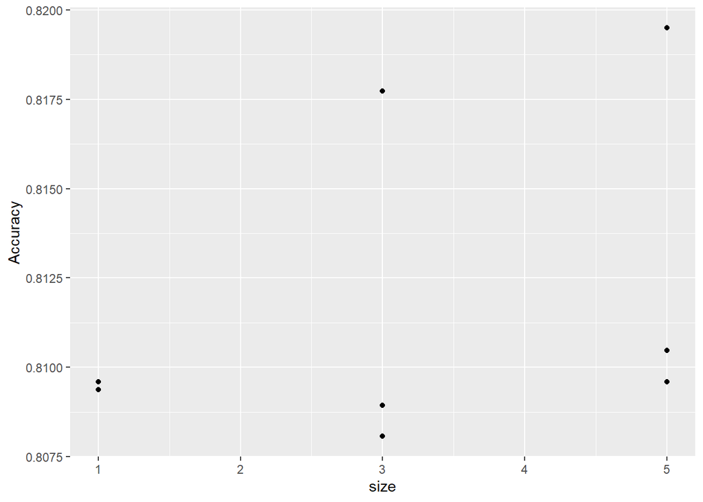

```r
ggplot(nn_model_Q2_purge$results,
      aes(x = size,
      y = Accuracy)) +
  geom_point()
```

Sur le tableau ci-dessus, la qualité de l’exactitude est à son maximun lorsque le nombre de couche est à 5.

## 3.3 Evaluation du modéle avec les données de test

```r
# Prediction avec le jeu de test
nn_test_pred_class <- predict(nn_model_Q2_purge, test_vin)
nn_test_pred_class %>% head(5)
```

```
## [1] no no no no no
## Levels: no yes
```

```r
#Matrice de confusion avec le jeu de test

nn_test_conf_mat = confusionMatrix(nn_test_pred_class,
                reference = test_vin$Class,
                positive = 'yes')
nn_test_conf_mat
```

```
## Confusion Matrix and Statistics
##
##           Reference
## Prediction   no  yes
##        no  1459  251
##        yes  107  132
##
##                Accuracy : 0.8163
##                  95% CI : (0.7984, 0.8333)
##     No Information Rate : 0.8035
##     P-Value [Acc > NIR] : 0.08041
##
##                   Kappa : 0.3221
##
##  Mcnemar's Test P-Value : 4.1e-14
##
##             Sensitivity : 0.34465
##             Specificity : 0.93167
##          Pos Pred Value : 0.55230
##          Neg Pred Value : 0.85322
##              Prevalence : 0.19651
##          Detection Rate : 0.06773
##    Detection Prevalence : 0.12263
##       Balanced Accuracy : 0.63816
##
##        'Positive' Class : yes
##
```

Avec les données du jeu de test l’exactitude est 0.8163161

# 4 Comparaison des deux modèles

## 4.1 Courbe ROC Modéle d’arbre de décision

Pour afficher des courbes ROC, il faut s’assurer que caret identifie la probabilité d’appartenance.

*Modéle d’arbre de décision*

```r
#Prédiction avec probabilité d'appartenance à la classe

dt_pred_prob <- predict(dt_model,
                        test_vin,
                        type = 'prob')
dt_pred_prob %>% head(5)
```

```
##          no        yes
## 1 0.9414041 0.05859591
## 2 0.2352941 0.76470588
## 3 0.8205424 0.17945759
## 4 0.8205424 0.17945759
## 5 0.9414041 0.05859591
```

```r
#preparation des courbes ROC Decision Tree
dt_roc_curve <- roc(response = test_vin$Class,
                    predictor = dt_pred_prob[,'yes'],
                    levels = levels(test_vin$Class))
```

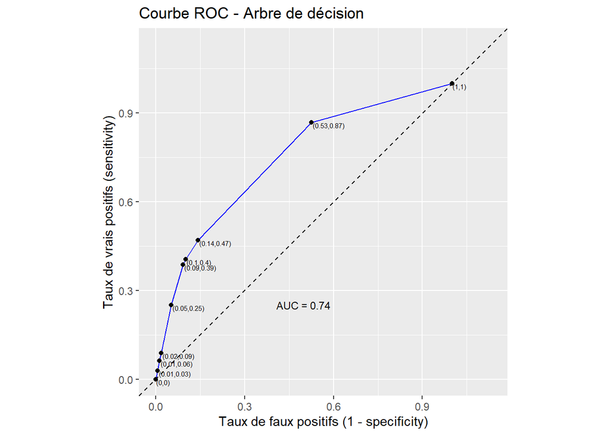

```r
#Visualisation des courbes ROC Decision Tree
df_roc_curve_dt = tibble(x = 1 - dt_roc_curve$specificities,
                          y = dt_roc_curve$sensitivities)

#tuto6a

ggplot(df_roc_curve_dt,
        aes(x = x,
        y = y)) +
  geom_line(colour='blue') +
  geom_point() +
  geom_abline(slope=1,
              intercept = 0,
              linetype='dashed') +
  coord_fixed(xlim = c(0, 1.13),
              ylim = c(0, 1.13)) +
  labs(x='Taux de faux positifs (1 - specificity)',
      y='Taux de vrais positifs (sensitivity)',
      title='Courbe ROC - Arbre de décision') +
  geom_text(aes(label=paste0('(',
                            round(x, 2),
                            ',',
                            round(y, 2),
                            ')'),
                hjust=-0.05,
                vjust=1),
          size = 2) +
  annotate('text',
          x=0.5,
          y=0.25,
          label = paste('AUC =',
                        round(auc(dt_roc_curve), 2)),
          size = 3)
```

## 4.2 Courbe ROC Modéle réseau de neurone

```r
# Prédiction avec les données de test
nn_predict_test_Q2 <- predict(nn_model_Q2_purge,
                              test_vin,
                              type = 'prob')
head(nn_predict_test_Q2)
```

```
##          no         yes
## 1 0.9853323 0.014667659
## 2 0.8409289 0.159071063
## 3 0.9569961 0.043003868
## 4 0.5386266 0.461373418
## 5 0.9836613 0.016338679
## 6 0.9949559 0.005044051
```

```r
#preparation des courbes ROC Decision Tree
dt_roc_curve <- roc(response = test_vin$Class,
                    predictor = dt_pred_prob[,'yes'],
levels = levels(test_vin$Class))


#preparation des courbes ROC - Réseau de Neurones
nn_roc_curve <- roc(response = test_vin$Class,
                    predictor = nn_predict_test_Q2[,'yes'])
```

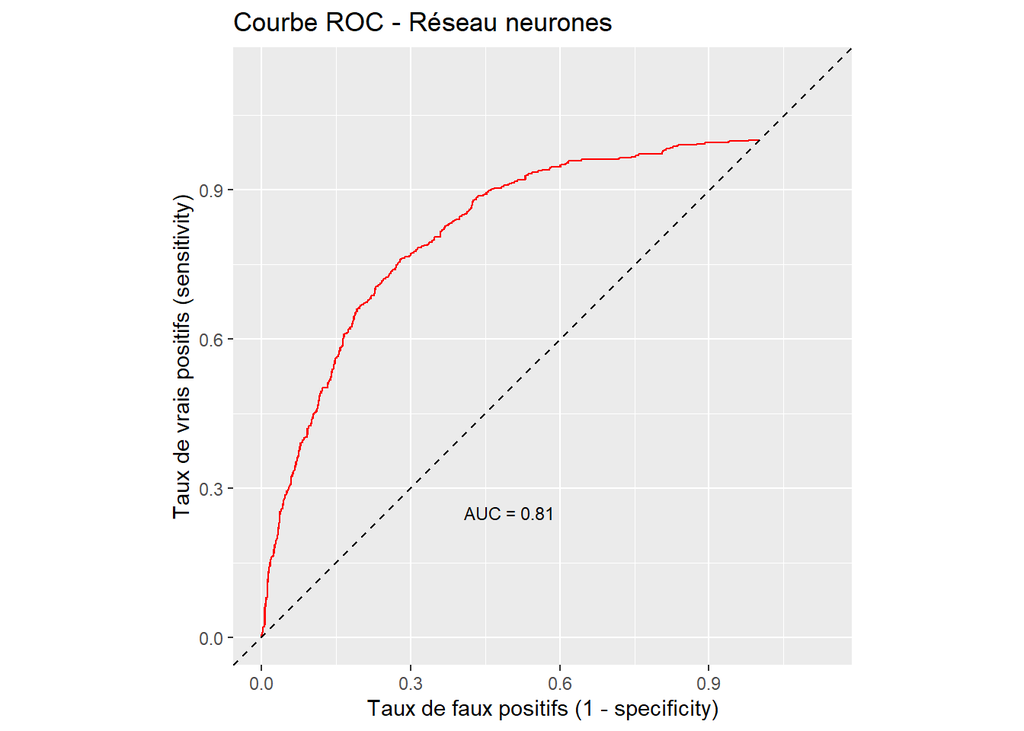

```r
#Visualisation des courbes ROC Reseau neurones
df_roc_curve_nn = tibble(x = 1 - nn_roc_curve$specificities,
                        y = nn_roc_curve$sensitivities)

#Graphique
ggplot(df_roc_curve_nn,
        aes(x = x,
        y = y)) +
  geom_line(colour='red')+
  geom_abline(slope=1,
              intercept = 0,
              linetype='dashed')+

  coord_fixed(xlim = c(0, 1.13),
              ylim = c(0, 1.13))+
  labs(x='Taux de faux positifs (1 - specificity)',
      y='Taux de vrais positifs (sensitivity)',
      title='Courbe ROC - Réseau neurones')+
  annotate('text',
         x=0.5,
        y=0.25,
       label = paste('AUC =',
                    round(auc(nn_roc_curve), 2)),
     size = 3)
```

Le modéle à base de Neurones est plus performant dans notre cas. L’exactitude des prédictions est supérieure :

Réseau de neurones : 0.8163161 Arbre de décision : 0.8111852

L’aire sous la courbe des résultats étant plus grande pour le reéseau de neurones, il prédit donc mieux que l’arbre de décision

Aire sous la courbe ROC du Réseau de neurones 0.8075621 Aire sous la courbe ROC de l’Arbre de décision 0.7399396

```r
nn_test_conf_mat$overall[1]
```

```
##  Accuracy
## 0.8163161
```

```r
dt_test_conf_mat$overall[1]
```

```
##  Accuracy
## 0.8111852
```